# R Notebook

```r
library(data.table)
```

```r
train <- fread("../Data/train.csv",header = T,stringsAsFactors = T)
```

```
##
Read 64.3% of 404290 rows
Read 98.9% of 404290 rows
Read 404290 rows and 6 (of 6) columns from 0.059 GB file in 00:00:04
```

```r
test <- fread("../Data/test.csv",header = T,stringsAsFactors = T)
```

```
##
Read 13.2% of 2345805 rows
Read 23.9% of 2345805 rows
Read 32.0% of 2345805 rows
Read 49.0% of 2345805 rows
Read 67.4% of 2345805 rows
Read 69.1% of 2345805 rows
Read 80.1% of 2345805 rows
Read 2345796 rows and 3 (of 3) columns from 0.292 GB file in 00:00:20
```

### Summary

```r
str(train)
```

```
## Classes 'data.table' and 'data.frame':   404290 obs. of  6 variables:
##  $ id          : Factor w/ 404290 levels "0","1","10","100",..: 1 2 111113 222224 333335 348736 359847 370958 382069 393180 ...
##  $ qid1        : Factor w/ 290654 levels "1","1000","100001",..: 1 124398 239187 270926 284117 6537 19451 32164 44815 57368 ...
##  $ qid2        : Factor w/ 299364 levels "10","100","10000",..: 64008 186748 272820 286160 1 12994 25854 38575 51316 64009 ...
##  $ question1   : Factor w/ 290457 levels " Can I pay with a debit card on PayPal?",..: 217300 217365 38219 263800 255645 6119 129406 33080 238899 125337 ...
##  $ question2   : Factor w/ 299175 levels ""," Any Canadian teachers (B.Ed. holders) teaching in U.S. schools?",..: 225280 241113 45297 29263 257678 106573 229651 233723 246980 59956 ...
##  $ is_duplicate: Factor w/ 2 levels "0","1": 1 1 1 1 1 2 1 2 1 1 ...
##  - attr(*, ".internal.selfref")=<externalptr>
```

```r
str(test)
```

```
## Classes 'data.table' and 'data.frame':   2345796 obs. of  3 variables:
##  $ test_id  : int  0 1 2 3 4 5 6 7 8 9 ...
##  $ question1: Factor w/ 2211009 levels ""," A tank 10m long and 5m wide has water up to a depth of 3m. What is the total area of the wet surface?",..: 561645 1018842 1278606 1906382 224701 246497 304484 50279 1222105 6227 ...
##  $ question2: Factor w/ 2227400 levels ""," A tank 10m long and 5m wide has water up to a depth of 3m. What is the total area of the wet surface?",..: 2067387 649789 1792877 1382377 702494 730517 308097 718739 1170567 75726 ...
##  - attr(*, ".internal.selfref")=<externalptr>
```

404290 unique IDs. But onlu 290654 factors in qid1. Similarly in qid2. *That means that lot of questions are repeating in q1 and q2* *Need to convert questions into character type*

### Change data types

```r
train$question1 <- as.character(train$question1)
train$question2 <- as.character(train$question2)
test$question1 <- as.character(test$question1)
test$question2 <- as.character(test$question2)
```

## EDA on train data

```r
summary(train)
```

```
##        id              qid1             qid2         question1
##  0      :     1   8461   :    50   30782  :   120   Length:404290
##  1      :     1   14110  :    48   2559   :   115   Class :character
##  10     :     1   1749   :    47   4044   :   100   Mode  :character
##  100    :     1   20628  :    47   2561   :    71
##  1000   :     1   25984  :    47   17978  :    66
##  10000  :     1   4951   :    46   14376  :    59
##  (Other):404284   (Other):404005   (Other):403759
##   question2         is_duplicate
##  Length:404290      0:255027
##  Class :character   1:149263
##  Mode  :character
##
##
##
##
```

No NAs in any of the columns. The question with qid1==8461 is repeating 50 times.

```r
train[train$qid1 == 8461,c(4,5)][1:10]
```

```
##                                 question1
##  1: How do I improve my English speaking?
##  2: How do I improve my English speaking?
##  3: How do I improve my English speaking?
##  4: How do I improve my English speaking?
##  5: How do I improve my English speaking?
##  6: How do I improve my English speaking?
##  7: How do I improve my English speaking?
##  8: How do I improve my English speaking?
##  9: How do I improve my English speaking?
## 10: How do I improve my English speaking?
##                                                   question2
##  1:           How do I improve my pronunciation in English?
##  2:              How can I specifically improve my English?
##  3:          How can I improve my English speaking ability?
##  4:          How can I improve my pronunciation in English?
##  5:    How can I improve my pronunciation of English words?
##  6:                         How could I improve my English?
##  7:      How can I improve my English in a very short time?
##  8: What is the best way to improve my spoken English soon?
##  9:               How can I improve English speaking skill?
## 10:                           I want to improve my English?
```

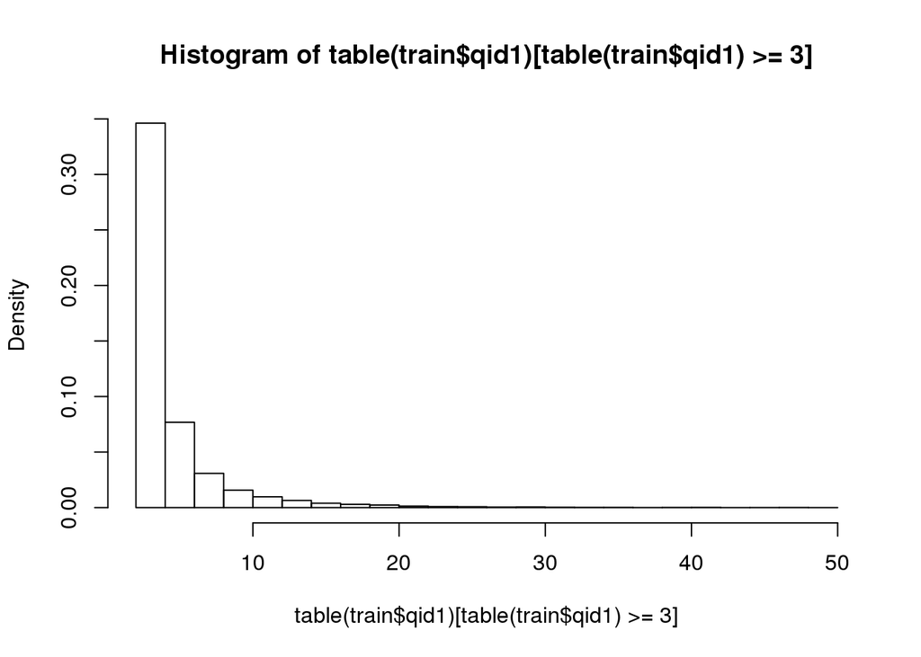

```r
hist(table(train$qid1)[table(train$qid1)>=3],breaks = 20,probability = T)
```

```r
sum(table(train$qid1)>=3)/nrow(train)
```

```
## [1] 0.05182666
```

~5% of the questions are repeated more than 3 times. Maybe they can be marked as duplicates.

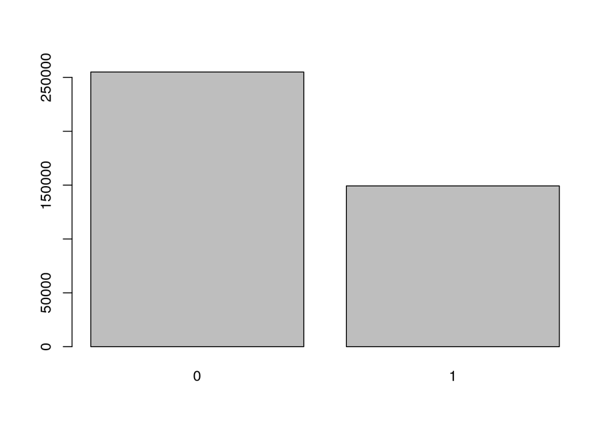

```r
barplot(table(train$is_duplicate))
```

Non duplicates are more than duplicates. Makes sense.

Are the questions which are repeated more than 3 times, duplicates or not duplicaes?

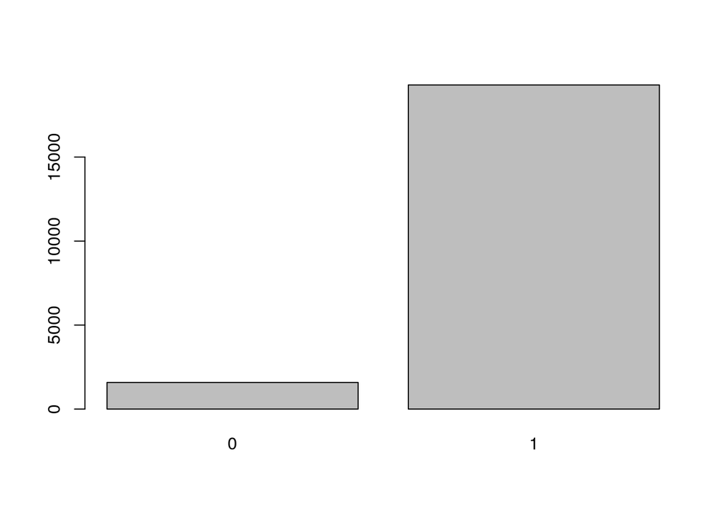

```r
freq5 <- as.data.frame(table(train$qid1)[table(train$qid1) >10])
barplot(table(train[train$qid1 %in% freq5$Var1,]$is_duplicate))
```

What about qid2 ?

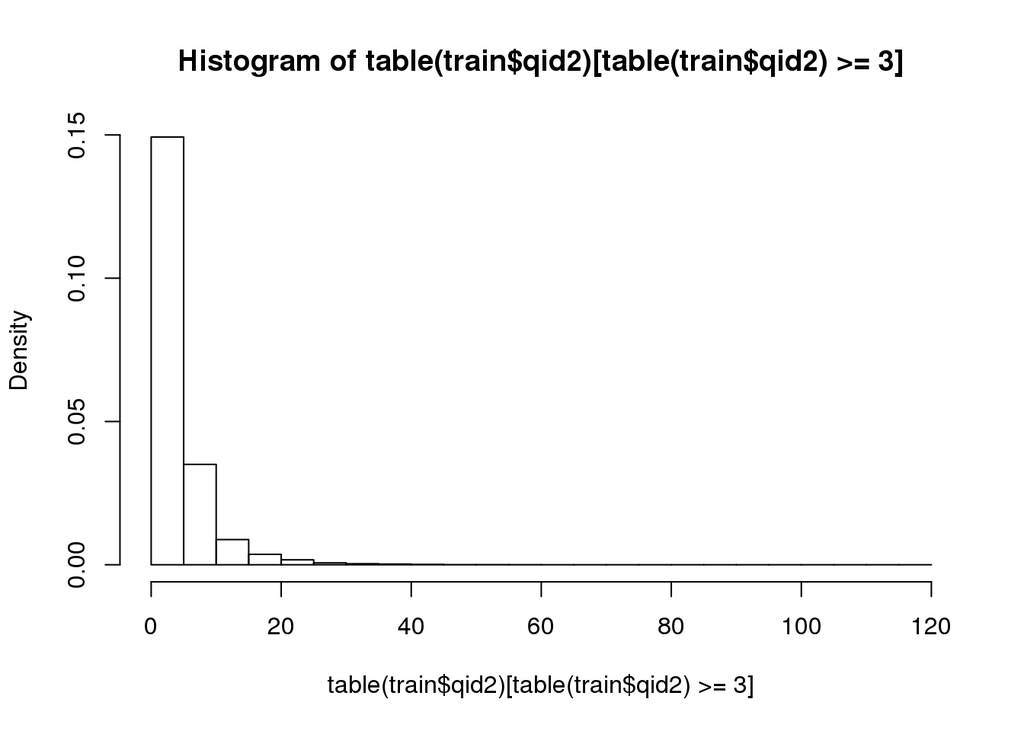

```r
hist(table(train$qid2)[table(train$qid2)>=3],breaks = 20,probability = T)
```

```r
sum(table(train$qid2)>=3)/nrow(train)
```

```
## [1] 0.04464617
```

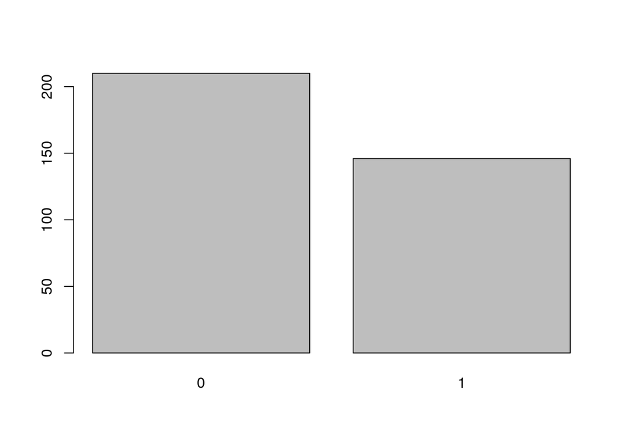

```r
freq5 <- as.data.frame(table(train$qid2)[table(train$qid1) >20])
barplot(table(train[train$qid2 %in% freq5$Var1,]$is_duplicate))
```

Looks like duplicates in qid2 is not giving enough separability. So, inference is that when qid1 is present more than 10 times in the entire data set, mark those rows are duplicated.

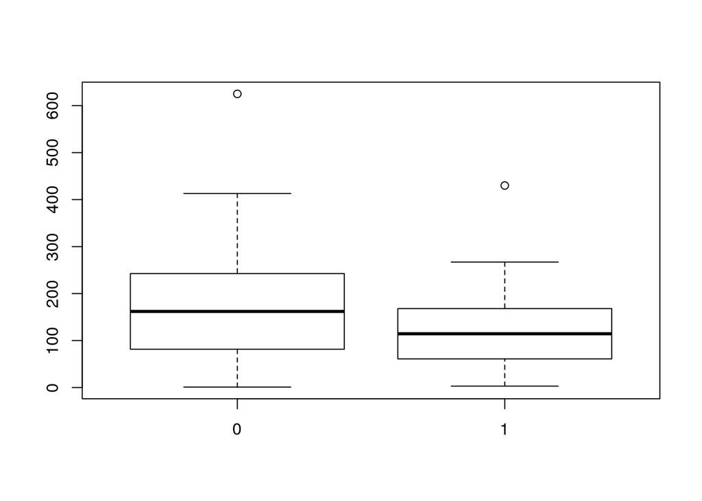

```r
#Check string length dependence

train$charlength1 <- nchar(train$question1)
train$charlength2 <- nchar(train$question2)

dt <- train[,j = (Count = .N),by = c("is_duplicate","charlength1")]
dt <- dt[order(charlength1)]

plot(dt$is_duplicate,dt$charlength1)
```

Shorter questions are slightly more likely to be duplicate. But, doesn’t look like it brings strong separateability. Still, could be one of the features in the classification model.

```r
train$nchar1 <- nchar(train$question1)
train$nchar2 <- nchar(train$question2)
```